# Week3 - COVID19 dataset

2022-03-14

## Set up

Add the libraries that you will need for functions within the code. Note that these libraries will need to be installed, if not already. The installs are not recommended to be included within the R Markdown.

## Data Source

The data is from Johns Hopkins University’s Data Repository of Covid-19 cases. It has data gathered from multiple authentic sources by the university.The data has Global Covid-19 cases and deaths by date, country and state, latitude and longitude. There is also a source for Global population by country and state.

## My Analysis

I would like to analyze the number of cases and deaths by country in relation to the country’s population.

## Bias

My assumption is that the number of cases and deaths will be higher in countries with a higher population.

## Read in the Dataset

I am currently prepping to import data by setting up a URL prefix that is common for all the files.

```r
url_in <- "https://raw.githubusercontent.com/CSSEGISandData/COVID-19/master/csse_covid_19_data/csse_covid_19_time_series/"
file_names <- c("time_series_covid19_confirmed_global.csv", "time_series_covid19_deaths_global.csv", "time_series_covid19_confirmed_US.csv", "time_series_covid19_deaths_US.csv")
urls <- str_c(url_in, file_names)
global_cases <- read_csv(urls[1])
global_deaths <- read_csv(urls[2])
US_cases <- read_csv(urls[3])
US_deaths <- read_csv(urls[4])
```

## Inspect Data by looking at it and modify the data set for what you need

```r
global_cases
```

```
## # A tibble: 284 x 796
##    `Province/State`  `Country/Region`   Lat   Long `1/22/20` `1/23/20` `1/24/20`
##    <chr>             <chr>            <dbl>  <dbl>     <dbl>     <dbl>     <dbl>
##  1 <NA>              Afghanistan       33.9  67.7          0         0         0
##  2 <NA>              Albania           41.2  20.2          0         0         0
##  3 <NA>              Algeria           28.0   1.66         0         0         0
##  4 <NA>              Andorra           42.5   1.52         0         0         0
##  5 <NA>              Angola           -11.2  17.9          0         0         0
##  6 <NA>              Antarctica       -71.9  23.3          0         0         0
##  7 <NA>              Antigua and Bar~  17.1 -61.8          0         0         0
##  8 <NA>              Argentina        -38.4 -63.6          0         0         0
##  9 <NA>              Armenia           40.1  45.0          0         0         0
## 10 Australian Capit~ Australia        -35.5 149.           0         0         0
## # ... with 274 more rows, and 789 more variables: `1/25/20` <dbl>,
## #   `1/26/20` <dbl>, `1/27/20` <dbl>, `1/28/20` <dbl>, `1/29/20` <dbl>,
## #   `1/30/20` <dbl>, `1/31/20` <dbl>, `2/1/20` <dbl>, `2/2/20` <dbl>,
## #   `2/3/20` <dbl>, `2/4/20` <dbl>, `2/5/20` <dbl>, `2/6/20` <dbl>,
## #   `2/7/20` <dbl>, `2/8/20` <dbl>, `2/9/20` <dbl>, `2/10/20` <dbl>,
## #   `2/11/20` <dbl>, `2/12/20` <dbl>, `2/13/20` <dbl>, `2/14/20` <dbl>,
## #   `2/15/20` <dbl>, `2/16/20` <dbl>, `2/17/20` <dbl>, `2/18/20` <dbl>, ...
```

## Tidy Data

Notice that you dont need Lat long for your analysis and the data needs to be pivoted to have the dates and their corresponding case counts on rows (one row per date)- so we pivot the data and drop the Lat long from global_cases. We do the same with global_deaths

```r
global_cases <- global_cases %>%
     pivot_longer(cols =
-c('Province/State',

'Country/Region',Lat,Long),
names_to="date",
values_to= "cases") %>%
   select(-c(Lat,Long))

global_deaths <- global_deaths %>%
     pivot_longer(cols =
-c('Province/State',

'Country/Region',Lat,Long),
names_to="date",
values_to= "deaths") %>%
   select(-c(Lat,Long))
```

## Combine all global data - cases and global_deaths

Also remove any records with cases = 0

```r
global <- global_cases %>%
     full_join(global_deaths) %>%
     rename(Country_Region  = 'Country/Region', Province_State = 'Province/State') %>%
     mutate(date = mdy(date))
global <- global %>% filter(cases>0)
summary(global)
```

```
##  Province_State     Country_Region          date                cases
##  Length:205619      Length:205619      Min.   :2020-01-22   Min.   :       1
##  Class :character   Class :character   1st Qu.:2020-09-10   1st Qu.:     601
##  Mode  :character   Mode  :character   Median :2021-03-18   Median :    8311
##                                        Mean   :2021-03-15   Mean   :  521051
##                                        3rd Qu.:2021-09-21   3rd Qu.:  130318
##                                        Max.   :2022-03-23   Max.   :79844430
##      deaths
##  Min.   :     0
##  1st Qu.:     4
##  Median :   114
##  Mean   : 10290
##  3rd Qu.:  2146
##  Max.   :974830
```

## Now clean up US data and combine cases and deaths

```r
US_cases <- US_cases %>%
  pivot_longer(cols = -(UID:Combined_Key),names_to = "date", values_to = "cases") %>%
  select(Admin2:cases) %>%
  mutate (date = mdy(date)) %>%
  select (-c(Lat,Long_))

US_deaths <- US_deaths %>%
  pivot_longer(cols = -(UID:Population),names_to = "date", values_to = "deaths") %>%
  select(Admin2:deaths) %>%
  mutate (date = mdy(date)) %>%
  select (-c(Lat,Long_))

US <- US_cases %>%
  full_join(US_deaths)
```

[output not shown]

## Add Population to the global dataset

```r
global <- global %>%
  unite("Combined_Key",
        c(Province_State, Country_Region),
        sep = ",",
        na.rm = TRUE,
        remove = FALSE)

uid_lookup <- 'https://raw.githubusercontent.com/CSSEGISandData/COVID-19/master/csse_covid_19_data/UID_ISO_FIPS_LookUp_Table.csv'
uid_lookup_url <- read_csv(uid_lookup) %>%
  select(-c(Lat,Long_, Combined_Key, code3, iso2, iso3, Admin2))
global <- global %>%
  left_join(uid_lookup_url, by = c("Province_State", "Country_Region"))  %>%
  select(-c(UID, FIPS)) %>%
  select(Province_State, Country_Region, date,
         cases, deaths, Population,
         Combined_Key)

global
```

```
## # A tibble: 205,619 x 7
##    Province_State Country_Region date       cases deaths Population Combined_Key
##    <chr>          <chr>          <date>     <dbl>  <dbl>      <dbl> <chr>
##  1 <NA>           Afghanistan    2020-02-24     5      0   38928341 Afghanistan
##  2 <NA>           Afghanistan    2020-02-25     5      0   38928341 Afghanistan
##  3 <NA>           Afghanistan    2020-02-26     5      0   38928341 Afghanistan
##  4 <NA>           Afghanistan    2020-02-27     5      0   38928341 Afghanistan
##  5 <NA>           Afghanistan    2020-02-28     5      0   38928341 Afghanistan
##  6 <NA>           Afghanistan    2020-02-29     5      0   38928341 Afghanistan
##  7 <NA>           Afghanistan    2020-03-01     5      0   38928341 Afghanistan
##  8 <NA>           Afghanistan    2020-03-02     5      0   38928341 Afghanistan
##  9 <NA>           Afghanistan    2020-03-03     5      0   38928341 Afghanistan
## 10 <NA>           Afghanistan    2020-03-04     5      0   38928341 Afghanistan
## # ... with 205,609 more rows
```

## Analyze and Visualize

```r
Global_by_Country <- global %>%
  group_by (Country_Region, date) %>%
  summarize(cases = sum(cases), deaths = sum(deaths), Population = sum(Population)) %>%
  mutate(deaths_per_mill = deaths * 1000000/Population) %>%
  mutate(cases_per_thou = cases * 1000/Population) %>%
  select(Country_Region, date, cases, deaths, Population, deaths_per_mill, cases_per_thou) %>%
  ungroup()
```

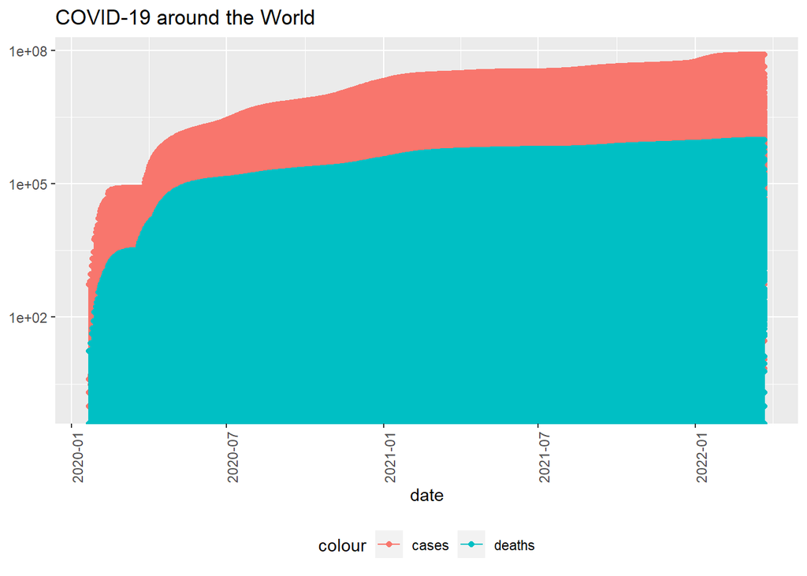

```r
ggplot1 <- Global_by_Country %>%
  filter(cases>0) %>%
  ggplot(aes(x=date, y = cases)) +
  geom_line(aes(color = "cases")) +
  geom_point(aes(color = "cases")) +
  geom_line(aes(y = deaths, color = "deaths")) +
  geom_point(aes(y = deaths, color = "deaths")) +
  scale_y_log10() +
  theme(legend.position = "bottom",
        axis.text.x = element_text(angle= 90)) +
  labs(title = "COVID-19 around the World", y = NULL)

plot(ggplot1)
```

## Visualize Cases, Deaths and Population of countries with the highest and lowest population (highest 30 and lowest30)

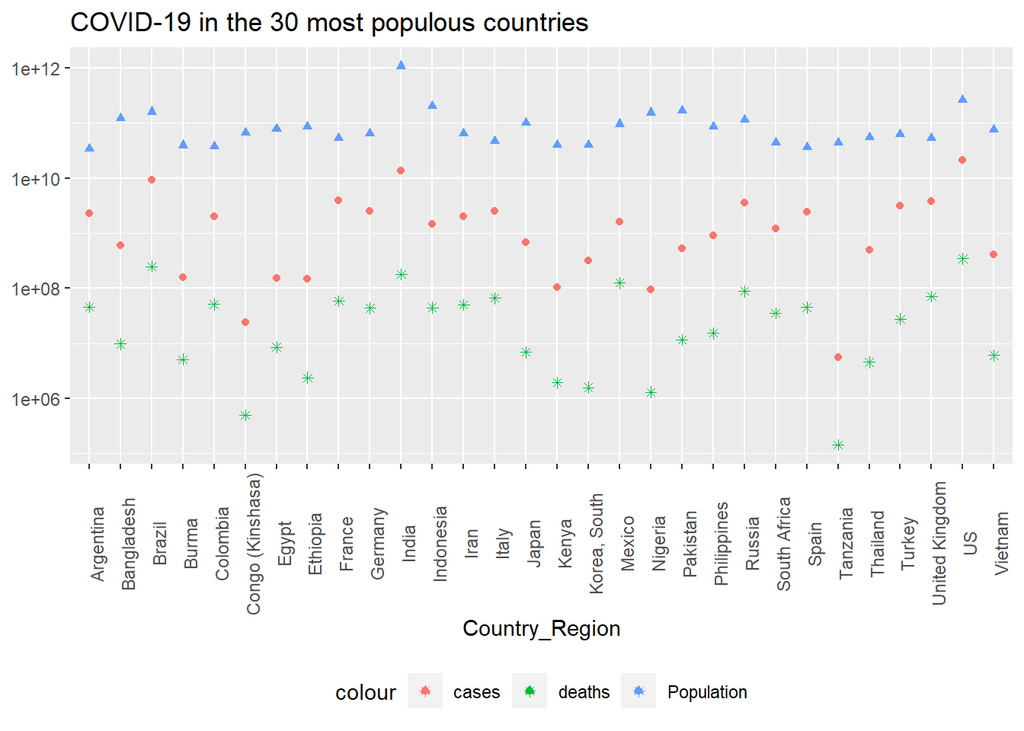

```r
Global_Summary_by_Country <- global %>%
  group_by (Country_Region) %>%
  summarize(cases = sum(cases), deaths = sum(deaths), Population = sum(Population)) %>%
  mutate(deaths_per_mill = deaths * 1000000/Population) %>%
  mutate(cases_per_thou = cases * 1000/Population) %>%
  select(Country_Region, cases, deaths, Population, deaths_per_mill, cases_per_thou) %>%
  ungroup()

Global_Summary_by_Country_top30 <- Global_Summary_by_Country %>%
  slice_max(Population, n=30)

ggplot3 <- ggplot(Global_Summary_by_Country_top30) +
  geom_point(aes(x=Country_Region, y=cases, colour = "cases")) +
  geom_point(aes(x=Country_Region, y=Population, colour = "Population"), shape = 17) +
  geom_point(aes(x=Country_Region, y=deaths, colour = "deaths"), shape = 8) +
  scale_y_log10() +
  theme(legend.position = "bottom",
        axis.text.x = element_text(angle= 90)) +
  labs(title = "COVID-19 in the 30 most populous countries", y = NULL)

plot(ggplot3)
```

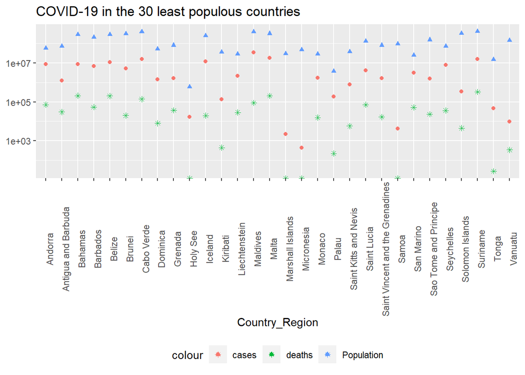

```r
Global_Summary_by_Country_bottom30 <- Global_Summary_by_Country %>%
  slice_min(Population, n=30)

ggplot4 <- ggplot(Global_Summary_by_Country_bottom30) +
  geom_point(aes(x=Country_Region, y=cases, colour = "cases")) +
  geom_point(aes(x=Country_Region, y=Population, colour = "Population"), shape = 17) +
  geom_point(aes(x=Country_Region, y=deaths, colour = "deaths"), shape = 8) +
  scale_y_log10() +
  theme(legend.position = "bottom",
        axis.text.x = element_text(angle= 90)) +
  labs(title = "COVID-19 in the 30 least populous countries", y = NULL)

plot(ggplot4)
```

## Model Data

### Linear Model to determine whether or how the deaths are related to cases. Predict deaths based on this model and compare with the actuals

```r
mod <- lm(deaths ~ cases, data = Global_by_Country)
summary(mod)
```

```
##
## Call:
## lm(formula = deaths ~ cases, data = Global_by_Country)
##
## Residuals:
##     Min      1Q  Median      3Q     Max
## -298444   -3150   -3058   -2574  267746
##
## Coefficients:
##              Estimate Std. Error t value Pr(>|t|)
## (Intercept) 3.060e+03  6.369e+01   48.04   <2e-16 ***
## cases       1.564e-02  1.774e-05  881.71   <2e-16 ***
## ---
## Signif. codes:  0 '***' 0.001 '**' 0.01 '*' 0.05 '.' 0.1 ' ' 1
##
## Residual standard error: 23620 on 143701 degrees of freedom
## Multiple R-squared:  0.844,  Adjusted R-squared:  0.844
## F-statistic: 7.774e+05 on 1 and 143701 DF,  p-value: < 2.2e-16
```

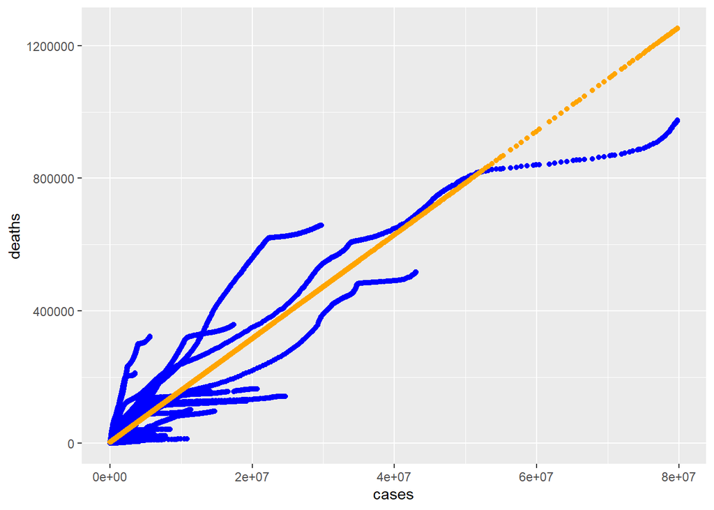

```r
Global_by_Country <- Global_by_Country %>%
  mutate(pred_deaths = predict(mod))

ggplot5 <- Global_by_Country %>%
  ggplot() +
  geom_point(aes(x= cases, y= deaths), color= "blue") +
  geom_point(aes(x= cases, y= pred_deaths), color= "orange")

plot(ggplot5)
```